# Dividend Discovery

```r
library(data.table)
library(rlang)
library(ggplot2)
library(ggrepel)
library(riingo)
library(tidyquant)
library(kableExtra)
library(RplotterPkg)
library(RtsaPkg)
```

Author: Rick Dean

Article date: 2020-12-20

Abstract

The following notes/R scripts were inspired from an article [Dividend Discovery](http://www.reproduciblefinance.com/2019/07/10/dividend-discovery/) by Jonathan Regenstein.

Note: Be aware that this application has an internet request for dividend data that will take time to complete.

# Dividend Discovery

## The data

### Set the Tiingo API key token

```r
riingo::riingo_set_token(RtsaPkg::read_tingo_key())
```

### Prepare the S&P 500 data

1. Using `tidyquant::tq_index()` get the tickers for S&P 500 index.

```r
sp_500_dt <- data.table::setDT(tidyquant::tq_index("SP500"))
str(sp_500_dt)
```

```
## Classes 'data.table' and 'data.frame':   506 obs. of  8 variables:
##  $ symbol        : chr  "AAPL" "MSFT" "AMZN" "FB" ...
##  $ company       : chr  "Apple Inc." "Microsoft Corporation" "Amazon.com Inc." "Facebook Inc. Class A" ...
##  $ identifier    : chr  "03783310" "59491810" "02313510" "30303M10" ...
##  $ sedol         : chr  "2046251" "2588173" "2000019" "B7TL820" ...
##  $ weight        : num  0.067 0.0538 0.0446 0.0214 0.0169 ...
##  $ sector        : chr  "Information Technology" "Information Technology" "Consumer Discretionary" "Communication Services" ...
##  $ shares_held   : num  1.66e+08 7.84e+07 4.41e+06 2.49e+07 3.11e+06 ...
##  $ local_currency: chr  "USD" "USD" "USD" "USD" ...
##  - attr(*, ".internal.selfref")=<externalptr>
```

2. Order the tickers by weight and select the top 30 S&P 500 tickers.

```r
tickers_dt <- sp_500_dt[order(-weight)][1:30]
tickers_dt[1:10]
```

```
##     symbol                         company identifier   sedol     weight
##  1:   AAPL                      Apple Inc.   03783310 2046251 0.06701805
##  2:   MSFT           Microsoft Corporation   59491810 2588173 0.05378284
##  3:   AMZN                 Amazon.com Inc.   02313510 2000019 0.04463207
##  4:     FB           Facebook Inc. Class A   30303M10 B7TL820 0.02137751
##  5:  GOOGL           Alphabet Inc. Class A   02079K30 BYVY8G0 0.01694042
##  6:   GOOG           Alphabet Inc. Class C   02079K10 BYY88Y7 0.01662309
##  7:  BRK.B Berkshire Hathaway Inc. Class B   08467070 2073390 0.01442697
##  8:    JNJ               Johnson & Johnson   47816010 2475833 0.01310839
##  9:    JPM            JPMorgan Chase & Co.   46625H10 2190385 0.01181418
## 10:      V               Visa Inc. Class A   92826C83 B2PZN04 0.01153944
##                     sector shares_held local_currency
##  1: Information Technology   166485390            USD
##  2: Information Technology    78366470            USD
##  3: Consumer Discretionary     4409512            USD
##  4: Communication Services    24900574            USD
##  5: Communication Services     3111791            USD
##  6: Communication Services     3040590            USD
##  7:             Financials    20529278            USD
##  8:            Health Care    27281276            USD
##  9:             Financials    31563216            USD
## 10: Information Technology    17470068            USD
```

3. Get historic stock market prices for the top 30 S&P 500 between “1990-01-01” and “2018-12-31”:

```r
prices_dt <- RtsaPkg::get_tiingo_stock_prices(symbols = tickers_dt$symbol, from = "1990-01-01", to = "2018-12-31")
str(prices_dt)
```

```
## Classes 'data.table' and 'data.frame':   170314 obs. of  14 variables:
##  $ Symbol     : Factor w/ 29 levels "AAPL","ADBE",..: 1 1 1 1 1 1 1 1 1 1 ...
##  $ Date       : Date, format: "1990-01-02" "1990-01-03" ...
##  $ Close      : num  37.2 37.5 37.6 37.8 38 ...
##  $ High       : num  37.5 38 38.8 38.2 38 ...
##  $ Low        : num  35 37.5 37.2 37 37 ...
##  $ Open       : num  35.2 38 38.2 37.8 37.5 ...
##  $ Volume     : int  1635700 1857100 1977800 1101000 906900 769100 1783200 1884400 1534800 1444100 ...
##  $ AdjClose   : num  0.268 0.27 0.271 0.272 0.273 ...
##  $ AdjHigh    : num  0.27 0.273 0.279 0.275 0.273 ...
##  $ AdjLow     : num  0.252 0.27 0.268 0.266 0.266 ...
##  $ AdjOpen    : num  0.254 0.273 0.275 0.272 0.27 ...
##  $ AdjVolume  : num  1.83e+08 2.08e+08 2.22e+08 1.23e+08 1.02e+08 ...
##  $ DivCash    : num  0 0 0 0 0 0 0 0 0 0 ...
##  $ SplitFactor: num  1 1 1 1 1 1 1 1 1 1 ...
##  - attr(*, ".internal.selfref")=<externalptr>
```

4. Select *Symbol*, *Date*, *Close*, *DivCash*

```r
dividends_dt <- prices_dt[, .(Date, Close, DivCash, Date_alt = as.IDate(Date)), by = Symbol]
str(dividends_dt)
```

```
## Classes 'data.table' and 'data.frame':   170314 obs. of  5 variables:
##  $ Symbol  : Factor w/ 29 levels "AAPL","ADBE",..: 1 1 1 1 1 1 1 1 1 1 ...
##  $ Date    : Date, format: "1990-01-02" "1990-01-03" ...
##  $ Close   : num  37.2 37.5 37.6 37.8 38 ...
##  $ DivCash : num  0 0 0 0 0 0 0 0 0 0 ...
##  $ Date_alt: IDate, format: "1990-01-02" "1990-01-03" ...
##  - attr(*, ".internal.selfref")=<externalptr>
```

Note: There are 29 symbols. One ticker is not supported by Tiingo – “BRK.B” Berkshire Hathaway Inc. Class B

## Dividend payments

### Select the most recent dividend payment

```r
dividends_latest_dt <- dividends_dt[DivCash > 0, .SD[.N], by = Symbol][order(-DivCash)]
dividends_latest_dt[1:10]
```

```
##     Symbol       Date  Close  DivCash   Date_alt
##  1:  GOOGL 2014-04-03 571.50 567.9717 2014-04-03
##  2:     HD 2018-11-28 177.43   1.0300 2018-11-28
##  3:    PEP 2018-12-06 116.84   0.9275 2018-12-06
##  4:    JNJ 2018-11-26 141.37   0.9000 2018-11-26
##  5:    UNH 2018-11-30 281.36   0.9000 2018-11-30
##  6:    DIS 2018-12-07 111.98   0.8800 2018-12-07
##  7:    JPM 2018-10-04 115.27   0.8000 2018-10-04
##  8:   AAPL 2018-11-08 208.49   0.7300 2018-11-08
##  9:     PG 2018-10-18  80.24   0.7172 2018-10-18
## 10:     VZ 2018-10-09  54.99   0.6025 2018-10-09
```

Note: the stock split that happened in 2014 for Google paid in the form of a dividend. We will filter this amount out along with just last dividends from 2018.

### Get the last posted dividends in 2018

```r
dividends_last_2018_dt <- dividends_dt[DivCash > 0 & DivCash < 200 & Date_alt > as.IDate("2017-12-31"),.SD[.N], by = Symbol][order(-DivCash)]
str(dividends_last_2018_dt)
```

```
## Classes 'data.table' and 'data.frame':   21 obs. of  5 variables:
##  $ Symbol  : Factor w/ 29 levels "AAPL","ADBE",..: 11 21 13 26 7 14 1 23 28 17 ...
##  $ Date    : Date, format: "2018-11-28" "2018-12-06" ...
##  $ Close   : num  177 117 141 281 112 ...
##  $ DivCash : num  1.03 0.927 0.9 0.9 0.88 ...
##  $ Date_alt: IDate, format: "2018-11-28" "2018-12-06" ...
##  - attr(*, ".internal.selfref")=<externalptr>
```

Note: we have 21 companies that posted dividends in the year 2018.

### Plot the dividends last posted in 2018

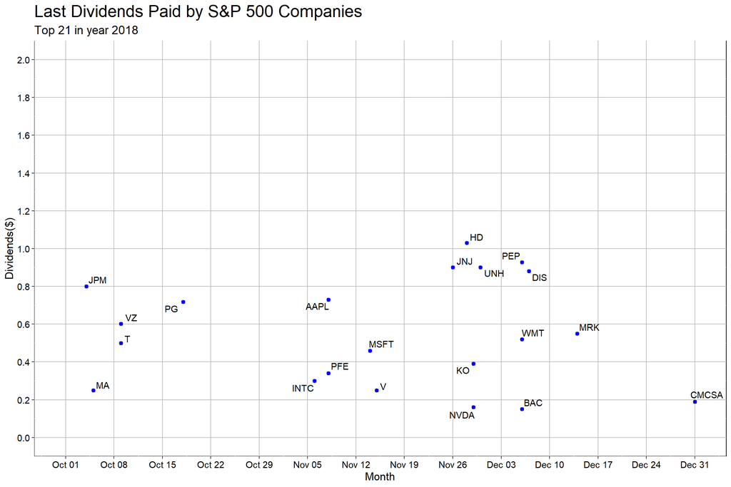

```r
RplotterPkg::create_scatter_plot(
  df = dividends_last_2018_dt,
  aes_x = "Date_alt",
  aes_y = "DivCash",
  title = "Last Dividends Paid by S&P 500 Companies",
  subtitle = "Top 21 in year 2018",
  x_title = "Month",
  y_title = "Dividends($)",
  x_limits = as.Date(c("2018-10-01", "2018-12-31")),
  x_major_breaks = seq(as.Date("2018-10-01"), as.Date("2018-12-31"), by="1 week"),
  x_date_labels = "%b %d",
  rot_y_tic_label = T,
  y_limits = c(0.0, 2.0),
  y_major_breaks = seq(0.0,2.0,0.2),
  pts_size = 1.2,
  pts_color = "blue",
  pts_fill = "blue",
  show_minor_grids = F
) + ggrepel::geom_text_repel(mapping = aes(label = Symbol))
```

## Compute the Total Annual Yield for 2018

Note: The Total Annual Yield (TAY) is defined as the sum of total dividends in 2018 divided by the closing price on the first dividend date.

1. Find the first dividend for each company in 2018:

```r
first_dividend_2018_dt <- dividends_dt[DivCash > 0 & DivCash < 200 & Date_alt > as.IDate("2017-12-31"), .SD[1L], by = Symbol][order(-DivCash)]
first_dividend_2018_dt[1:10]
```

```
##     Symbol       Date  Close DivCash   Date_alt
##  1:     HD 2018-03-07 178.58  1.0300 2018-03-07
##  2:    DIS 2018-07-06 104.78  0.8400 2018-07-06
##  3:    JNJ 2018-02-26 132.07  0.8400 2018-02-26
##  4:    PEP 2018-03-01 108.12  0.8050 2018-03-01
##  5:    UNH 2018-03-08 224.73  0.7500 2018-03-08
##  6:     PG 2018-01-18  90.18  0.6896 2018-01-18
##  7:   AAPL 2018-02-09 156.41  0.6300 2018-02-09
##  8:     VZ 2018-01-09  51.61  0.5900 2018-01-09
##  9:    JPM 2018-01-04 109.04  0.5600 2018-01-04
## 10:    WMT 2018-03-08  87.92  0.5200 2018-03-08
```

2. Find the sum of the total dividends in 2018:

```r
sum_dividend_2018_dt <- dividends_dt[DivCash > 0 & DivCash < 200 & Date_alt > as.IDate("2017-12-31"), lapply(.SD, sum), by = Symbol, .SDcols = "DivCash"][order(-DivCash)]
sum_dividend_2018_dt <- sum_dividend_2018_dt[, .(Symbol, TotalDivCash = DivCash)]
sum_dividend_2018_dt[1:10]
```

```
##     Symbol TotalDivCash
##  1:     HD       4.1200
##  2:    PEP       3.5875
##  3:    JNJ       3.5400
##  4:    UNH       3.4500
##  5:     PG       2.8412
##  6:   AAPL       2.8200
##  7:    JPM       2.4800
##  8:     VZ       2.3725
##  9:    WMT       2.0800
## 10:      T       2.0000
```

3. Outer join both data.tables:

```r
data.table::setkey(first_dividend_2018_dt, "Symbol")
data.table::setkey(sum_dividend_2018_dt, "Symbol")
tay_dividend_2018_dt <- first_dividend_2018_dt[sum_dividend_2018_dt]
tay_dividend_2018_dt[1:10]
```

```
##     Symbol       Date  Close DivCash   Date_alt TotalDivCash
##  1:   AAPL 2018-02-09 156.41  0.6300 2018-02-09       2.8200
##  2:    BAC 2018-03-01  31.48  0.1200 2018-03-01       0.5400
##  3:  CMCSA 2018-01-02  41.07  0.1575 2018-01-02       0.9175
##  4:    DIS 2018-07-06 104.78  0.8400 2018-07-06       1.7200
##  5:     HD 2018-03-07 178.58  1.0300 2018-03-07       4.1200
##  6:   INTC 2018-02-06  44.91  0.3000 2018-02-06       1.2000
##  7:    JNJ 2018-02-26 132.07  0.8400 2018-02-26       3.5400
##  8:    JPM 2018-01-04 109.04  0.5600 2018-01-04       2.4800
##  9:     KO 2018-03-14  43.78  0.3900 2018-03-14       1.5600
## 10:     MA 2018-01-08 159.27  0.2500 2018-01-08       1.0000
```

4. Compute `TAY = (TotalDivCash/Close) * 100`:

```r
tay_dividend_2018_dt <- tay_dividend_2018_dt[, TAY := (TotalDivCash/Close)*100][order(-TAY)]
tay_dividend_2018_dt[1:10]
```

```
##     Symbol       Date  Close DivCash   Date_alt TotalDivCash      TAY
##  1:      T 2018-01-09  37.49  0.5000 2018-01-09       2.0000 5.334756
##  2:     VZ 2018-01-09  51.61  0.5900 2018-01-09       2.3725 4.596977
##  3:    PFE 2018-02-01  36.83  0.3400 2018-02-01       1.3600 3.692642
##  4:    MRK 2018-03-14  54.80  0.4800 2018-03-14       1.9900 3.631387
##  5:     KO 2018-03-14  43.78  0.3900 2018-03-14       1.5600 3.563271
##  6:    PEP 2018-03-01 108.12  0.8050 2018-03-01       3.5875 3.318073
##  7:     PG 2018-01-18  90.18  0.6896 2018-01-18       2.8412 3.150588
##  8:    JNJ 2018-02-26 132.07  0.8400 2018-02-26       3.5400 2.680397
##  9:   INTC 2018-02-06  44.91  0.3000 2018-02-06       1.2000 2.672011
## 10:    WMT 2018-03-08  87.92  0.5200 2018-03-08       2.0800 2.365787
```

5. Plot the TAY:

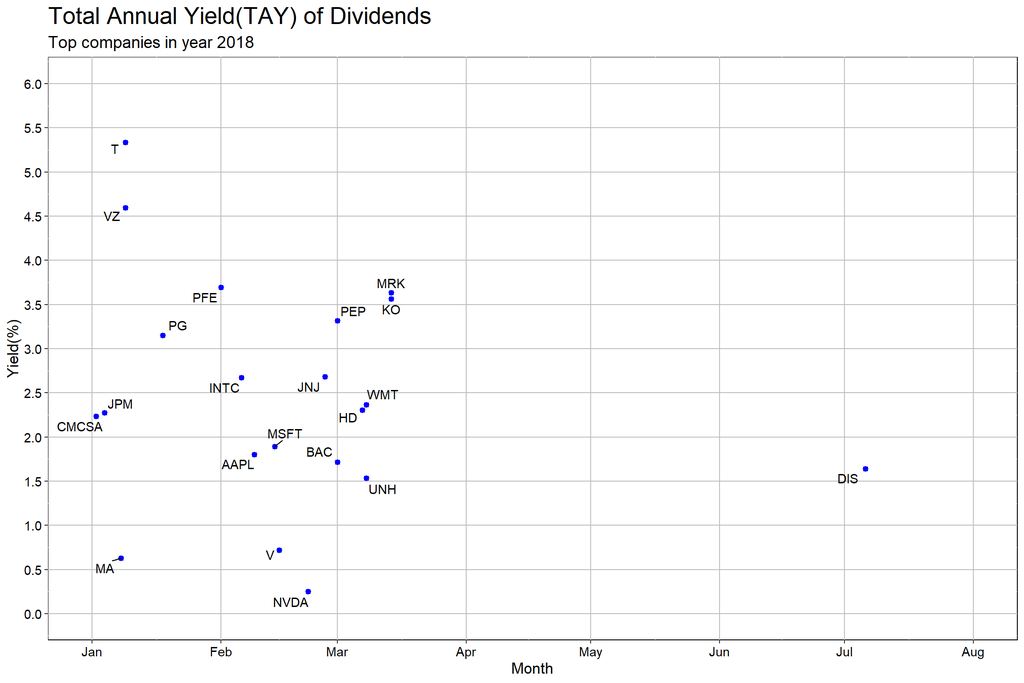

```r
RplotterPkg::create_scatter_plot(
  df = tay_dividend_2018_dt,
  aes_x = "Date_alt",
  aes_y = "TAY",
  title = "Total Annual Yield(TAY) of Dividends",
  subtitle = "Top companies in year 2018",
  x_title = "Month",
  y_title = "Yield(%)",
  x_limits = as.Date(c("2018-01-01", "2018-08-01")),
  x_major_breaks = seq(as.Date("2018-01-01"), as.Date("2018-08-01"), by="1 month"),
  x_date_labels = "%b",
  rot_y_tic_label = TRUE,
  y_limits = c(0.0, 6.0),
  y_major_breaks = seq(0.0,6.0,0.5),
  pts_size = 1.2,
  pts_color = "blue",
  pts_fill = "blue",
  show_minor_grids = F
) + ggrepel::geom_text_repel(mapping = aes(label = Symbol))
```

## Dividends across the years

1. Add a *year* variable to `dividends_dt`:

```r
dividends_dt[, Year := as.numeric(format(Date_alt, "%Y"))]
dividends_dt[1:10]
```

```
##     Symbol       Date Close DivCash   Date_alt Year
##  1:   AAPL 1990-01-02 37.25       0 1990-01-02 1990
##  2:   AAPL 1990-01-03 37.50       0 1990-01-03 1990
##  3:   AAPL 1990-01-04 37.63       0 1990-01-04 1990
##  4:   AAPL 1990-01-05 37.75       0 1990-01-05 1990
##  5:   AAPL 1990-01-08 38.00       0 1990-01-08 1990
##  6:   AAPL 1990-01-09 37.63       0 1990-01-09 1990
##  7:   AAPL 1990-01-10 36.00       0 1990-01-10 1990
##  8:   AAPL 1990-01-11 34.50       0 1990-01-11 1990
##  9:   AAPL 1990-01-12 34.50       0 1990-01-12 1990
## 10:   AAPL 1990-01-15 34.25       0 1990-01-15 1990
```

2. Compute the total yearly dividend payout for each company each year:

```r
dividends_yearly_dt <- dividends_dt[, .(Total_Div = sum(DivCash)), by = .(Symbol, Year)]
dividends_yearly_dt[1:10]
```

```
##     Symbol Year Total_Div
##  1:   AAPL 1990      0.45
##  2:   AAPL 1991      0.48
##  3:   AAPL 1992      0.48
##  4:   AAPL 1993      0.48
##  5:   AAPL 1994      0.48
##  6:   AAPL 1995      0.48
##  7:   AAPL 1996      0.00
##  8:   AAPL 1997      0.00
##  9:   AAPL 1998      0.00
## 10:   AAPL 1999      0.00
```

Note: For *AAPL* there was a stock split in years 2012, 2013, 2014 and then back down to $2 in 2015.

3. Create a column that shows increase/decrease from the previous year:

```r
dividends_yearly_dt[, Div_Increase := ifelse(Total_Div > shift(Total_Div,1), 1, 0)]
dividends_yearly_dt <- na.omit(dividends_yearly_dt, cols = "Div_Increase")
dividends_yearly_dt[1:10]
```

```
##     Symbol Year Total_Div Div_Increase
##  1:   AAPL 1991      0.48            1
##  2:   AAPL 1992      0.48            0
##  3:   AAPL 1993      0.48            0
##  4:   AAPL 1994      0.48            0
##  5:   AAPL 1995      0.48            0
##  6:   AAPL 1996      0.00            0
##  7:   AAPL 1997      0.00            0
##  8:   AAPL 1998      0.00            0
##  9:   AAPL 1999      0.00            0
## 10:   AAPL 2000      0.00            0
```

4. Get the total increases for each company:

```r
dividend_increases_dt = dividends_yearly_dt[, lapply(.SD, sum), by = Symbol, .SDcols = "Div_Increase"]
dividend_increases_totals_dt <- dividend_increases_dt[, .(Symbol, Div_Increase_Total = Div_Increase)]
dividend_increases_totals_dt <- dividend_increases_totals_dt[order(-Div_Increase_Total)]
dividend_increases_totals_dt[1:10]
```

```
##     Symbol Div_Increase_Total
##  1:    PEP                 26
##  2:    WMT                 24
##  3:     PG                 23
##  4:     HD                 22
##  5:    JNJ                 22
##  6:      T                 22
##  7:     KO                 21
##  8:    BAC                 20
##  9:    MRK                 20
## 10:    PFE                 18
```

5. Plot the increases:

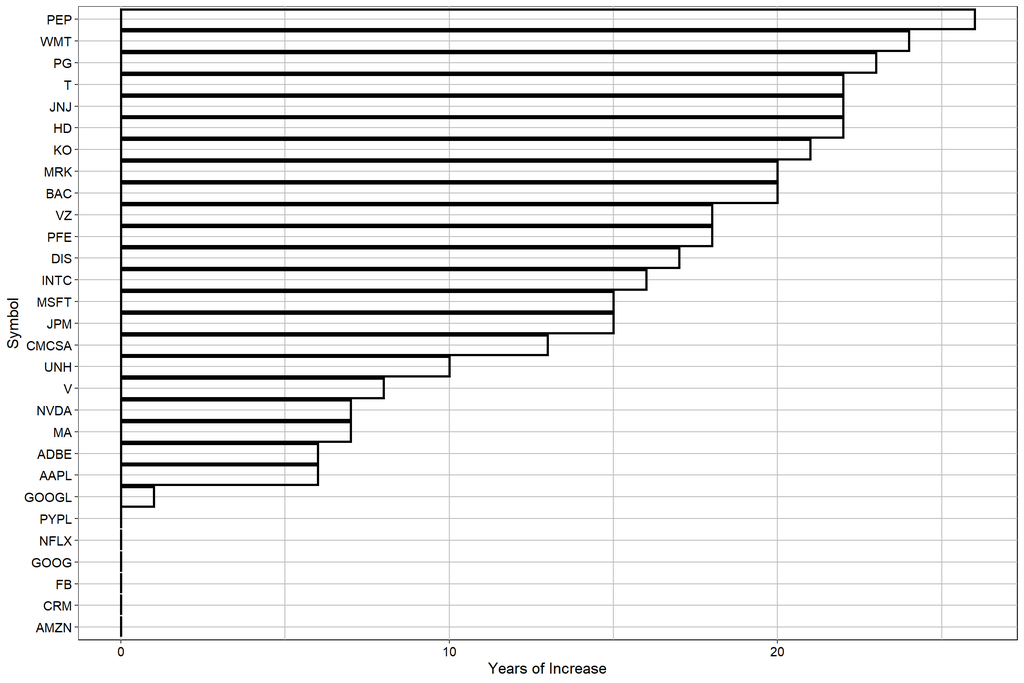

```r
RplotterPkg::create_bar_plot(
  df = dividend_increases_totals_dt,
  aes_x = "Symbol",
  aes_y = "Div_Increase_Total",
  do_coord_flip = T,
  rot_y_tic_label = T,
  y_title = "Years of Increase",
  order_bars = "asc"
)
```